# Make A Nice Bar Plot

Yu Wang

This is a brife introuduction on how to make a nice bar plot with 95% confidence interval as error bar and the significant marks between the pairwised comparsion group.

Firstly, clean the environment space of R and set a working dictionary.

```r
rm(list=ls())

#setwd('replace the direction with your own working file path here')
```

## Then prepare the bar plot data set in the next step.

Here we make a fake data set with four outcomes(a, b, c, d) and four treatment groups (Treat1,Treat2, Treat3, Treat4, Treat1).

```r
set.seed(123)
f.data<-as.data.frame(outer(rnorm(200,2,2),rnorm(4,4,1),'*'))
colnames(f.data)<-c('a','b','c','d')
f.data$group<-sample(rep(c('Treat1','Treat2','Treat3','Treat4'),50))
```

Then the first 6 rows of our fake data is looks like the following.

```r
head(f.data)
```

```
##           a        b         c         d  group
## 1  5.449056  4.66987  3.283119  3.993689 Treat4
## 2  9.543967  8.17923  5.750351  6.994906 Treat4
## 3 31.721895 27.18583 19.112809 23.249417 Treat3
## 4 13.271757 11.37397  7.996387  9.727055 Treat4
## 5 14.000481 11.99849  8.435452 10.261147 Treat3
## 6 33.660346 28.84709 20.280748 24.670134 Treat2
```

Then we calculate the four group means for each outcome by the following code.

```r
M.a<-tapply(f.data$a,f.data$group,function(x){mean(x,na.rm = T)})
M.b<-tapply(f.data$b,f.data$group,function(x){mean(x,na.rm = T)})
M.c<-tapply(f.data$c,f.data$group,function(x){mean(x,na.rm = T)})
M.d<-tapply(f.data$d,f.data$group,function(x){mean(x,na.rm = T)})
```

Combine the four mean vector into a 4*4 matrix.

```r
M.matrix<-cbind(M.a,M.b,M.c,M.d)
M.matrix
```

```
##             M.a       M.b      M.c       M.d
## Treat1 13.99601 11.994650 8.432755 10.257866
## Treat2 13.77458 11.804890 8.299346 10.095583
## Treat3 11.15430  9.559298 6.720598  8.175145
## Treat4 10.24058  8.776228 6.170066  7.505461
```

Similarly, we calculate the four group standard error for each outcome by the following code.

```r
se.a<-tapply(f.data$a,f.data$group,function(x){sqrt(var(x,na.rm=TRUE)/length(na.omit(x)))})
se.b<-tapply(f.data$b,f.data$group,function(x){sqrt(var(x,na.rm=TRUE)/length(na.omit(x)))})
se.c<-tapply(f.data$c,f.data$group,function(x){sqrt(var(x,na.rm=TRUE)/length(na.omit(x)))})
se.d<-tapply(f.data$d,f.data$group,function(x){sqrt(var(x,na.rm=TRUE)/length(na.omit(x)))})
```

Combined the four se vector into a 4*4 matrix too.

```r
se.matrix<-cbind(se.a,se.b,se.c,se.d)
se.matrix
```

```
##            se.a     se.b      se.c      se.d
## Treat1 1.455169 1.247088 0.8767564 1.0665138
## Treat2 1.863304 1.596862 1.1226624 1.3656416
## Treat3 1.874220 1.606217 1.1292394 1.3736420
## Treat4 1.336737 1.145590 0.8053992 0.9797127
```

Now we can calculate the 95% confidence interval’s up-bound and lower-bound matrix.

```r
u.b<-M.matrix+se.matrix*1.96
l.b<-M.matrix-se.matrix*1.96
u.b
```

```
##             M.a      M.b       M.c       M.d
## Treat1 16.84814 14.43894 10.151198 12.348234
## Treat2 17.42666 14.93474 10.499764 12.772240
## Treat3 14.82778 12.70748  8.933907 10.867483
## Treat4 12.86058 11.02158  7.748648  9.425698
```

```r
l.b
```

```
##              M.a      M.b      M.c      M.d
## Treat1 11.143873 9.550358 6.714313 8.167499
## Treat2 10.122507 8.675041 6.098927 7.418925
## Treat3  7.480833 6.411113 4.507288 5.482806
## Treat4  7.620573 6.530871 4.591484 5.585224
```

## Started to creat the bar plot from here.

first plot the basic bar plot by the following code.

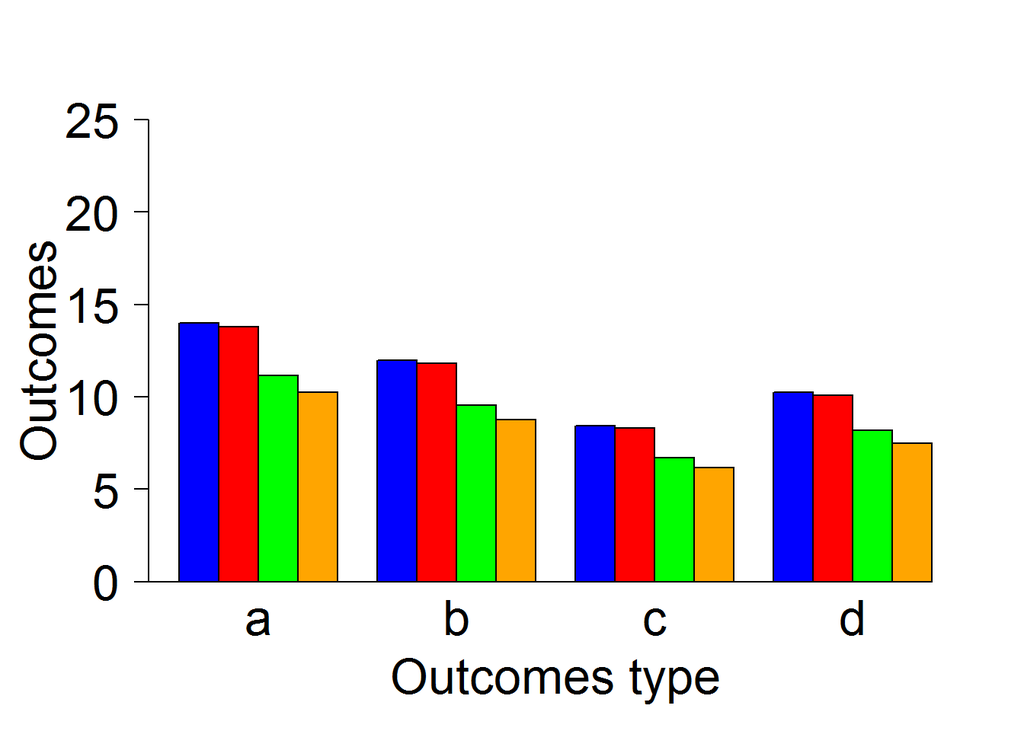

```r
par(mfrow = c(1, 1),cex.axis=2,cex.lab=2,cex.main=2,mar=c(5.1,5.1,4.1,2.1))
barCenters <-barplot(M.matrix,beside=T,names.arg=c('a','b','c','d'), las=1,xlab='Outcomes type' ,col=c('blue','red','green','orange'), ylim=c(0,round(max(u.b)*1.45)),ylab='Outcomes',xpd=T)
segments(0,0,floor(max(barCenters)),0)
```

Now we can add the 95% confidence interval error bars for each bar.

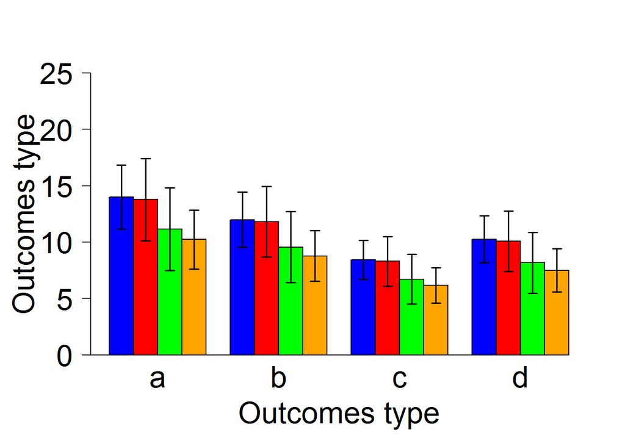

```r
par(mfrow = c(1, 1),cex.axis=2,cex.lab=2,cex.main=2,mar=c(5.1,5.1,4.1,2.1))
barCenters <-barplot(M.matrix,beside=T,names.arg=c('a','b','c','d'), las=1,xlab='Outcomes type'  ,col=c('blue','red','green','orange'), ylim=c(0,round(max(u.b)*1.45)),ylab='Outcomes type',xpd=T)
segments(0,0,floor(max(barCenters)),0)
####### following is the added code ###########
arrows(barCenters,l.b, barCenters,u.b, lwd = 1.5, angle = 90, code = 3, length = 0.05)
```

Here we define a function for easily add the significant marks for the compared groups by the following code.

```r
Sig.mark<-function(x0,x1,y,len){
  segments(x0,y-len,x0,y)
  segments(x0,y,x1,y)
  segments(x1,y-len,x1,y)
  text(0.5*(x1+x0),y*1.05,'**',col='red',cex = 2)
}
```

If we applied the statistic test and found the significant difference between the Treat1 and Treat4 in outcome a. Then the following code can add a significant mark between the corrsponding bars.

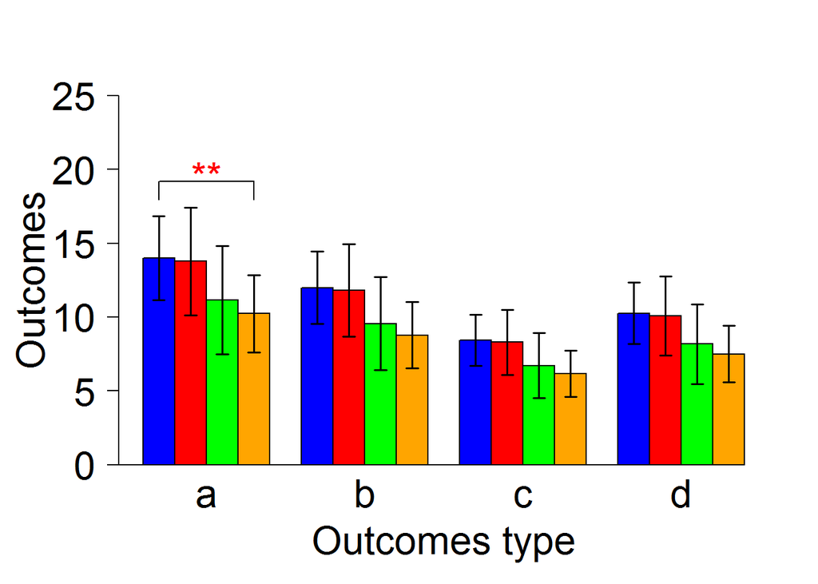

```r
par(mfrow = c(1, 1),cex.axis=2,cex.lab=2,cex.main=2,mar=c(5.1,5.1,4.1,2.1))
barCenters <-barplot(M.matrix,beside=T,names.arg=c('a','b','c','d'),
                     las=1,xlab='Outcomes type'  ,col=c('blue','red','green','orange'), ylim=c(0,round(max(u.b)*1.45)),ylab='Outcomes',xpd=T)
segments(0,0,floor(max(barCenters)),0)
arrows(barCenters,l.b, barCenters,u.b, lwd = 1.5, angle = 90,code = 3, length = 0.05)
####### following is the added new code ###################
Sig.mark(barCenters[1,1],barCenters[4,1],max(u.b[,1])*1.1,max(u.b)*0.07)
```

Note: the each column in barCenter martix represents one bar group or one outcome bar group and each row represents one treatment. Hence, if you want to add a significant mark between treatment 1 and teatment 4 in outcome 1, the indext of barCenters in function sig.mark is [1,1] first and [4,1] second.

The last step is add the legend for our bar plot by the following code. The following part is also the entire code to creat the fianl version of bar plot.

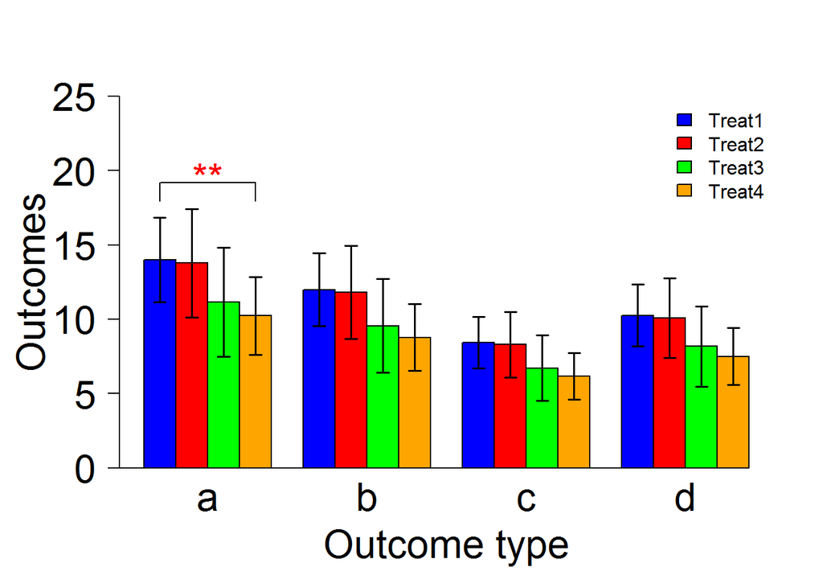

```r
par(mfrow = c(1, 1),cex.axis=2,cex.lab=2,cex.main=2,mar=c(5.1,5.1,4.1,2.1))
barCenters <-barplot(M.matrix,beside=T, names.arg=c('a','b','c','d'),
las=1,xlab='Outcome type'  ,col=c('blue','red','green','orange'), ylim=c(0,round(max(u.b)*1.45)),ylab='Outcomes',xpd=T)
segments(0,0,floor(max(barCenters)),0)
arrows(barCenters,l.b, barCenters,u.b, lwd = 1.5, angle = 90,code = 3, length = 0.05)
Sig.mark(barCenters[1,1],barCenters[4,1],max(u.b[,1])*1.1,max(u.b)*0.07)

############### following is the added new code ###################

legend('topright',fill =c('blue','red','green','orange'),legend =c('Treat1','Treat2','Treat3','Treat4'),bty = "n",xpd=T)
```

Now we can save the final plot into a PDF file, then it can be easily transformed into jpg, tif, or png format.